[O’Hara on GitHub](https://github.com/oharac)

# Upstream-downstream taxa vulnerability gapfill

Compiled on Sun Mar 6 17:31:52 2022 by ohara

```r
knitr::opts_chunk$set(fig.width = 6, fig.height = 4, fig.path = 'figs/',
                      echo = TRUE, message = FALSE, warning = FALSE)

library(oharac) ### remotes::install_github('oharac/oharac')
library(tidyverse)
library(here)
source(here('common_fxns.R'))
options(dplyr.summarise.inform = FALSE)

### directory on server for large files:
dir_mazu <- '/home/shares/ohi/spp_vuln/spp_vuln_framework'
```

# 1 Summary

Using taxonomic trees from WoRMS and the `taxize` package, we will try filling vulnerabilities for non-scored species using an upstream-downstream method.

# 2 Methods

- For a given rank, calculate distribution parameters based on all known downstream spp (e.g., for genus, calc mean and sd based on all scored spp)
- Then assign those back down to unknown species at the species level.
- For data given at the genus level (or above), this effectively automatically gapfills all species in the genus.
- Repeat for higher levels

## 2.1 Load expanded vulnerability scores

These have already been scrubbed of confounding symbols and parenthetical genera… to avoid problems of tiny differences in mean and sd, round to 4 decimal places. There are also several conflicting taxonomic classifications of families with multiple orders (WoRMS order noted):

- ophiacanthidae (ophiacanthida)
- labridae (eupercaria incertae sedis)
- apogonidae (kurtiformes)

Coerce these appropriately - each spp is listed only for one order, so no additional wrangling is needed.

```r
match_spp <- read_csv(here('int/spp_match_downfill.csv'), show_col_types = FALSE)
spp_vuln  <- read_csv(here('int/vuln_downfill_only.csv'), show_col_types = FALSE)

match_vuln_df <- match_spp %>%
  inner_join(spp_vuln, by = 'downfill_spp_id') %>%
  mutate(order = case_when(family == 'apogonidae' ~ 'kurtiformes',
                           family == 'labridae' ~ 'eupercaria incertae sedis',
                           family == 'ophiacanthidae' ~ 'ophiacanthida',
                           TRUE ~ order)) %>%
  mutate(sd_vuln = ifelse(is.na(sd_vuln), 0, sd_vuln)) %>%
  mutate(vuln    = round(vuln, 4),
         sd_vuln = round(sd_vuln, 4))
```

## 2.2 Assemble full spp table from WoRMS

Use the `assemble_worms()` function from `common_fxns.R`.

```r
spp_all_wide <- assemble_worms('wide')
spp_all_long <- assemble_worms('long')
```

### 2.2.1 Potential for gapfill at each rank

For each rank, identify the taxa included in vulnerability data (e.g. which genera are included in our data, based on any match level). Count the number of species known (from vulnerability data), unknown but fillable (not specifically in vulnerability data), and unknown and unfillable (no vulnerability for that taxa).

```r
taxa_match_df <- match_vuln_df %>%
  select(phylum:species) %>%
  distinct() %>%
  group_by(species) %>%
  ungroup()

match_ranks <- c('phylum', 'class', 'order', 'family', 'genus', 'species')

rank_gapfill_potential <- vector('list', length = length(match_ranks) - 1) %>%
  setNames(match_ranks[-6])

for(r in match_ranks[-6]) { ### r <- 'phylum'
  rank_spp_known <- taxa_match_df %>%
    rename(tmp := !!r) %>%
    group_by(tmp) %>%
    summarize(n_spp_known = n_distinct(species)) %>%
    ungroup() %>%
    rename(!!r := tmp)
  rank_spp_all <- spp_all_wide %>%
    rename(tmp := !!r) %>%
    group_by(tmp) %>%
    summarize(n_spp_all = n_distinct(species)) %>%
    ungroup() %>%
    rename(!!r := tmp) %>%
    left_join(rank_spp_known, by = r) %>%
    mutate(n_spp_fill = ifelse(is.na(n_spp_known), 0, n_spp_all - n_spp_known))
  rank_gapfill_potential[[r]] <- rank_spp_all %>%
    summarize(n_spp_known = sum(n_spp_known, na.rm = TRUE),
              n_spp_fill = sum(n_spp_fill),
              n_spp_unknown = sum(n_spp_all) - n_spp_known - n_spp_fill,
              n_spp_all = sum(n_spp_all),
              rank = r)
}
knitr::kable(bind_rows(rank_gapfill_potential))
```

| n_spp_known | n_spp_fill | n_spp_unknown | n_spp_all | rank |
| --- | --- | --- | --- | --- |
| 30030 | 148506 | 40340 | 218876 | phylum |
| 30030 | 112390 | 76456 | 218876 | class |
| 30030 | 60824 | 128022 | 218876 | order |
| 30030 | 13039 | 175807 | 218876 | family |
| 30030 | 1468 | 187378 | 218876 | genus |

## 2.3 create gapfill dataframes

Calculate the mean based on all $n$ known species in the rank-level grouping. This will be broken into taxa with all vulnerability scores deterministic (i.e., no species with a distribution around its vulnerability score) and probabilistic (i.e., one or more species has a distribution around its vulnerability score).

For deterministic taxa, we can calculate a simple mean and standard deviation across vulnerability scores for all species in the taxon.

For probabilistic taxa, we will do a Monte Carlo approach, sampling species from the taxon including variation around the mean for those species with distributions around their vulnerability.

### 2.3.1 Deterministic taxa

This code takes ranks where all species in the rank have a deterministic vulnerability score for a given stressor (i.e., no variation in imputed vulnerability due to trait variation), and then summarizes across these species to get a mean and standard deviation for that rank and that stressor.

```r
### Because this seems to keep stalling when crunching genus,
### break into chunks by a higher rank, process separately, then recombine
ords <- match_vuln_df %>%
  group_by(order) %>%
  summarize(n_spp = n_distinct(species)) %>%
  .$order

rank_fill_det <- function(ord, ranks) {
  ### ord <- ords[5]
  rank_lvls <- c('kingdom', 'phylum', 'class', 'order', 'family', 'genus', 'species')
  ### find the max rank (max == most specific)
  ranks_fct <- factor(ranks, levels = rank_lvls)
  gp_rank <- ranks_fct[which.max(ranks_fct)] %>% as.character()

  message('processing ', paste(ranks, collapse = '/'), ', chunking order ', ord)
  det_tmp <- match_vuln_df %>%
    filter(order == ord) %>%
    group_by(!!!syms(gp_rank), stressor, taxon) %>%
    mutate(tmp = sum(sd_vuln > 0, na.rm = TRUE)) %>%
    filter(tmp == 0) %>%
    group_by(!!!syms(ranks), stressor, taxon) %>%
    summarize(n_spp_known = n_distinct(species),
              mean_vuln = mean(vuln),
              sd_vuln   = sd(vuln), ### this line is causing lags
              # sd_vuln2 = sqrt( sum((vuln - mean_vuln)^2) / (n_spp_known - 1) ),
              .groups = 'drop')
  # message('wrapping up order ', ord)
  return(det_tmp)
}

gen_fill_det <- parallel::mclapply(ords, mc.cores = 20,
                  FUN = rank_fill_det,
                  ranks = c('class', 'order', 'family', 'genus')) %>%
  bind_rows()
    ### placeholder for additional moments
      # med_vuln  = median(vuln),
      # skew_vuln = psych::skew(vuln, type = 2),
      # kurt_vuln = psych::kurtosi(vuln, type = 2),
      # bimod_coef = mousetrap::bimodality_coefficient(vuln),
      # gapfill = 'genus')
message('...done with genus')

fam_fill_det <- parallel::mclapply(ords, mc.cores = 20,
                  FUN = rank_fill_det,
                  ranks = c('class', 'order', 'family')) %>%
  bind_rows()
message('...done with family')

ord_fill_det <- match_vuln_df %>%
  group_by(class, order, stressor, taxon) %>%
  mutate(tmp = sum(sd_vuln > 0, na.rm = TRUE)) %>%
  filter(tmp == 0) %>%
  summarize(n_spp_known = n_distinct(species),
            mean_vuln = mean(vuln),
            sd_vuln   = sd(vuln),
            .groups = 'drop')
message('...done with order')

cls_fill_det <- match_vuln_df %>%
  group_by(class, stressor, taxon) %>%
  mutate(tmp = sum(sd_vuln > 0, na.rm = TRUE)) %>%
  filter(tmp == 0) %>%
  summarize(n_spp_known = n_distinct(species),
            mean_vuln = mean(vuln),
            sd_vuln   = sd(vuln),
            .groups = 'drop')
message('...done with class')
```

### 2.3.2 Probabilistic taxa

If any species in the taxon has a distribution around its vulnerability for a stressor (i.e., sd(vulnerability) != 0, due to multiple trait values), check a few things:

- `gen_fill_matchrank`: Are all species in the taxon gapfilled from this rank or a higher rank? if so, no gapfilling is necessary, as the downstream fill has already necessarily filled all values.
- `gen_fill_nondet_solo`: Are there more than one unique value for vuln and sd_vuln among species within this rank group? If not, then all spp have identical distributions. In this case, it is likely that a single probabilistic species represents the entire genus (or whichever level). Note: ignore ones entirely gapfilled from a higher level.
- `gen_fill_prob`: Leaving out groups matched at higher ranks and species with only one distinct instance of vulnerability values, these remain, with multiple species within the rank group having different vulnerability scores and distributions.

```r
stressors <- match_vuln_df$stressor %>% unique() %>% sort()
```

Let’s also tally up the number of species in each rank-level group (e.g., # of species in a given genus or family).

```r
count_ranks <- match_ranks[1:5]
count_list <- vector('list', length = length(count_ranks)) %>%
  setNames(count_ranks)
for(rank in count_ranks) {
  ### rank <- count_ranks[1]
  rank_df <- spp_all_wide %>%
    rename(name := !!rank) %>%
    group_by(name) %>%
    summarize(n_spp_total = n_distinct(species)) %>%
    mutate(rank = rank) %>%
    distinct()
  count_list[[rank]] <- rank_df
}
count_df <- bind_rows(count_list)
```

#### 2.3.2.1 Genus level

```r
gen_fill_nondet <- match_vuln_df %>%
  group_by(class, order, family, genus, stressor, taxon) %>%
  filter(sum(sd_vuln > 0, na.rm = TRUE) > 0) %>%
  ungroup()

gen_fill_matchrank <- gen_fill_nondet %>%
  group_by(class, order, family, genus, stressor, taxon) %>%
  filter(all(match_rank %in% c('class', 'order', 'family', 'genus'))) %>%
  summarize(mean_vuln = first(vuln),
            sd_vuln = first(sd_vuln),
            n_spp_known = n_distinct(species)) %>%
  ungroup()

gen_fill_nondet_solo <- gen_fill_nondet %>%
  filter(!genus %in% gen_fill_matchrank$genus) %>%
  group_by(class, order, family, genus, stressor, taxon) %>%
  filter(n_distinct(vuln) == 1 & n_distinct(sd_vuln) == 1) %>%
  summarize(mean_vuln = first(vuln),
            sd_vuln = first(sd_vuln),
            n_spp_known = n_distinct(species)) %>%
  ungroup()
```

```r
iters <- 10000
reload <- FALSE
force  <- FALSE

gen_fill_file <- here('int', sprintf('gapfill_gen_prob_results_%s.csv', iters))
# unlink(gen_fill_file)
if(!file.exists(gen_fill_file) | reload) {

  if(force) {
    unlink(list.files(here('tmp'), pattern = 'gen_fill_mc.+.csv', full.names = TRUE))
  }

  gen_fill_prob <- gen_fill_nondet %>%
    anti_join(gen_fill_matchrank %>% select(genus, stressor)) %>%
    anti_join(gen_fill_nondet_solo %>% select(genus, stressor)) %>%
    group_by(class, order, family, genus, stressor, taxon)

  gen_fill_qty <- gen_fill_prob %>%
    group_by(class, order, family, genus, stressor, taxon) %>%
    summarize(n_spp = n(),
              n_prob = sum(sd_vuln > 0, na.rm = TRUE)) %>%
    filter(n_spp > 1) %>%
    ungroup()

  genera <- gen_fill_qty$genus %>% unique() %>% sort()

  tmp_fstem <- here('tmp/gen_fill_mc_%s.csv')

  trash <- parallel::mclapply(genera, mc.cores = 12,
    FUN = function(g) {### g <- genera[1]
      tmp_file <- sprintf(tmp_fstem, g)
      if(!file.exists(tmp_file)) {
        # unlink(tmp_file)
        g_df <- gen_fill_prob %>%
          filter(genus == g) %>%
          mutate(sd_vuln = ifelse(is.na(sd_vuln), 0, sd_vuln))

        message('Sampling ', iters, ' MC iterations for genus ', g)

        mc_results_df <- g_df %>%
          rowwise() %>%
          mutate(v = list(rnorm(iters, mean = vuln, sd = sd_vuln))) %>%
          unnest(v) %>%
          mutate(v = case_when(v < 0 ~ 0, v > 1 ~ 1, TRUE ~ v)) %>%
          group_by(class, order, family, genus, stressor, taxon) %>%
          summarize(mean_vuln = mean(v),
                    sd_vuln = sd(v),
                    # med_vuln = median(v),
                    n_spp_known = n_distinct(species)) %>%
          ungroup()

        write_csv(mc_results_df, tmp_file)
      }
    })

  genera_fs <- list.files(here('tmp'), pattern = 'gen_fill_mc.+.csv',
                            full.names = TRUE)
  genera_list <- parallel::mclapply(genera_fs, FUN = read_csv, show_col_types = FALSE, mc.cores = 20)
  gen_fill_prob_results <- genera_list %>%
    bind_rows()

  if(nrow(gen_fill_prob_results) != nrow(gen_fill_qty)) {
    stop('Mismatch row counts in genus level MC fill!')
  }
  gen_fill_prob_results <- gen_fill_prob_results %>%
    left_join(gen_fill_qty)

  write_csv(gen_fill_prob_results, gen_fill_file)
}
```

combine all genus-level gapfill values:

```r
gen_fill_prob_results <- read_csv(gen_fill_file, show_col_types = FALSE)

gen_fill_totes <- bind_rows(gen_fill_det,
                            gen_fill_matchrank,
                            gen_fill_nondet_solo,
                            gen_fill_prob_results) %>%
  select(-n_spp) %>%
  mutate(gapfill = 'genus') %>%
  left_join(count_df, by = c('genus' = 'name', 'gapfill' = 'rank'))

check <- gen_fill_totes %>%
  group_by(genus) %>%
  summarize(n_str = n_distinct(stressor), n_vals = sum(!is.na(mean_vuln)))
```

#### 2.3.2.2 Family level

```r
fam_fill_nondet <- match_vuln_df %>%
  group_by(class, order, family, stressor, taxon) %>%
  filter(sum(sd_vuln > 0, na.rm = TRUE) > 0) %>%
  ungroup()

fam_fill_matchrank <- fam_fill_nondet %>%
  group_by(class, order, family, stressor, taxon) %>%
  filter(all(match_rank %in% c('class', 'order', 'family'))) %>%
  summarize(mean_vuln = first(vuln),
            # med_vuln = first(vuln),
            sd_vuln = first(sd_vuln),
            n_spp_known = n_distinct(species)) %>%
  ungroup()

fam_fill_nondet_solo <- fam_fill_nondet %>%
  filter(!family %in% fam_fill_matchrank$family) %>%
  group_by(class, order, family, stressor, taxon) %>%
  filter(n_distinct(vuln) == 1 & n_distinct(sd_vuln) == 1) %>%
  summarize(mean_vuln = first(vuln),
            # med_vuln = first(vuln),
            sd_vuln = first(sd_vuln),
            n_spp_known = n_distinct(species)) %>%
  ungroup()
```

```r
fam_fill_file <- here('int', sprintf('gapfill_fam_prob_results_%s.csv', iters))
### unlink(fam_fill_file)
if(!file.exists(fam_fill_file) | reload) {

  if(force) {
    unlink(list.files(here('tmp'), pattern = 'fam_fill_mc.+.csv', full.names = TRUE))
  }

  fam_fill_prob <- fam_fill_nondet %>%
    anti_join(fam_fill_matchrank %>% select(family, stressor)) %>%
    anti_join(fam_fill_nondet_solo %>% select(family, stressor)) %>%
    group_by(class, order, family, stressor, taxon)

  fam_fill_qty <- fam_fill_prob %>%
    group_by(class, order, family, stressor, taxon) %>%
    summarize(n_spp = n(),
              n_prob = sum(sd_vuln > 0, na.rm = TRUE)) %>%
    filter(n_spp > 1) %>%
    ungroup()

  fams <- fam_fill_qty$family %>% unique() %>% sort()

  tmp_fstem <- here('tmp/fam_fill_mc_%s.csv')

  trash <- parallel::mclapply(fams, mc.cores = 8,
    FUN = function(f) {### f <- fams[1]
      tmp_file <- sprintf(tmp_fstem, f)
      if(!file.exists(tmp_file)) {
        # unlink(tmp_file)
        f_df <- fam_fill_prob %>%
          filter(family == f) %>%
          mutate(sd_vuln = ifelse(is.na(sd_vuln), 0, sd_vuln))

        message('Sampling ', iters, ' MC iterations for family ', f)

        mc_results_df <- f_df %>%
          rowwise() %>%
          mutate(v = list(rnorm(iters, mean = vuln, sd = sd_vuln))) %>%
          unnest(v) %>%
          mutate(v = case_when(v < 0 ~ 0, v > 1 ~ 1, TRUE ~ v)) %>%
          group_by(class, order, family, stressor, taxon) %>%
          summarize(mean_vuln = mean(v),
                    sd_vuln = sd(v),
                    # med_vuln = median(v),
                    n_spp_known = n_distinct(species)) %>%
          ungroup()

        write_csv(mc_results_df, tmp_file)
      }
    })

  family_fs <- list.files(here('tmp'), pattern = 'fam_fill_mc.+.csv',
                            full.names = TRUE)
  fam_list <- parallel::mclapply(family_fs, FUN = read_csv, show_col_types = FALSE, mc.cores = 20)
  fam_fill_prob_results <- fam_list %>%
    bind_rows()

  if(nrow(fam_fill_prob_results) != nrow(fam_fill_qty)) {
    stop('Mismatch row counts in family level MC fill!')
  }

  fam_fill_prob_results <- fam_fill_prob_results %>%
    left_join(fam_fill_qty)

  write_csv(fam_fill_prob_results, fam_fill_file)
}
```

combine all family-level gapfill values:

```r
fam_fill_prob_results <- read_csv(fam_fill_file, show_col_types = FALSE)

fam_fill_totes <- bind_rows(fam_fill_det,
                            fam_fill_matchrank,
                            fam_fill_nondet_solo,
                            fam_fill_prob_results) %>%
  select(-n_spp) %>%
  mutate(gapfill = 'family') %>%
  left_join(count_df, by = c('family' = 'name', 'gapfill' = 'rank'))

check <- fam_fill_totes %>%
  group_by(family) %>%
  summarize(n_str = n_distinct(stressor), n_vals = sum(!is.na(mean_vuln)))
```

#### 2.3.2.3 Order level

```r
ord_fill_nondet <- match_vuln_df %>%
  # filter(genus == 'meridiastra') %>%
  group_by(class, order, stressor, taxon) %>%
  filter(sum(sd_vuln > 0, na.rm = TRUE) > 0) %>%
  ungroup()

ord_fill_matchrank <- ord_fill_nondet %>%
  group_by(class, order, stressor, taxon) %>%
  filter(all(match_rank %in% c('class', 'order'))) %>%
  summarize(mean_vuln = first(vuln),
            # med_vuln = first(vuln),
            sd_vuln = first(sd_vuln),
            n_spp_known = n_distinct(species)) %>%
  ungroup()

ord_fill_nondet_solo <- ord_fill_nondet %>%
  filter(!order %in% ord_fill_matchrank$order) %>%
  group_by(class, order, stressor, taxon) %>%
  filter(n_distinct(vuln) == 1 & n_distinct(sd_vuln) == 1) %>%
  summarize(mean_vuln = first(vuln),
            # med_vuln = first(vuln),
            sd_vuln = first(sd_vuln),
            n_spp_known = n_distinct(species)) %>%
  ungroup()
```

```r
iters <- 5000 ### set to fewer iterations - should be plenty
ord_fill_file <- here('int', sprintf('gapfill_ord_prob_results_%s.csv', iters))
### unlink(ord_fill_file)

if(!file.exists(ord_fill_file) | reload) {

  if(force) {
    unlink(list.files(here('tmp'), pattern = 'ord_fill_mc.+.csv', full.names = TRUE))
  }

  ord_fill_prob <- ord_fill_nondet %>%
    anti_join(ord_fill_matchrank %>% select(order, stressor)) %>%
    anti_join(ord_fill_nondet_solo %>% select(order, stressor)) %>%
    group_by(class, order, stressor, taxon)

  ord_fill_qty <- ord_fill_prob %>%
    group_by(class, order, stressor, taxon) %>%
    summarize(n_spp = n(),
              n_prob = sum(sd_vuln > 0, na.rm = TRUE)) %>%
    filter(n_spp > 1) %>%
    ungroup()

  ords <- ord_fill_qty$order %>% unique() %>% sort()

  tmp_fstem <- here('tmp/ord_fill_mc_%s.csv')

  # trash <- parallel::mclapply(ords, mc.cores = 1, ### memory intensive!
  trash <- lapply(ords,
    FUN = function(o) {### o <- ords[1]
      tmp_file <- sprintf(tmp_fstem, o)
      if(!file.exists(tmp_file)) {
        # unlink(tmp_file)
        o_df <- ord_fill_prob %>%
          filter(order == o) %>%
          mutate(sd_vuln = ifelse(is.na(sd_vuln), 0, sd_vuln))

        message('Sampling ', iters, ' MC iterations for order ', o)

        mc_results_df <- o_df %>%
          rowwise() %>%
          mutate(v = list(rnorm(iters, mean = vuln, sd = sd_vuln))) %>%
          unnest(v) %>%
          mutate(v = case_when(v < 0 ~ 0, v > 1 ~ 1, TRUE ~ v)) %>%
          group_by(class, order, stressor, taxon) %>%
          summarize(mean_vuln = mean(v),
                    sd_vuln = sd(v),
                    # med_vuln = median(v),
                    n_spp_known = n_distinct(species)) %>%
          ungroup()

        write_csv(mc_results_df, tmp_file)
      }
    })

  ord_fs <- list.files(here('tmp'), pattern = 'ord_fill_mc.+.csv',
                            full.names = TRUE)
  ord_list <- parallel::mclapply(ord_fs, FUN = read_csv, show_col_types = FALSE, mc.cores = 20)

  ord_fill_prob_results <- ord_list %>%
    bind_rows()

  if(nrow(ord_fill_prob_results) != nrow(ord_fill_qty)) {
    stop('Mismatch row counts in order level MC fill!')
  }

  ord_fill_prob_results <- ord_fill_prob_results %>%
    left_join(ord_fill_qty)

  write_csv(ord_fill_prob_results, ord_fill_file)
}
```

combine all order-level gapfill values:

```r
ord_fill_prob_results <- read_csv(ord_fill_file, show_col_types = FALSE)

ord_fill_totes <- bind_rows(ord_fill_det,
                            ord_fill_matchrank,
                            ord_fill_nondet_solo,
                            ord_fill_prob_results) %>%
  select(-n_spp) %>%
  mutate(gapfill = 'order') %>%
  left_join(count_df, by = c('order' = 'name', 'gapfill' = 'rank'))

check <- ord_fill_totes %>%
  group_by(order) %>%
  summarize(n_str = n_distinct(stressor), n_vals = sum(!is.na(mean_vuln)))
```

#### 2.3.2.4 Class level

```r
cls_fill_nondet <- match_vuln_df %>%
  # filter(genus == 'meridiastra') %>%
  group_by(class, stressor, taxon) %>%
  filter(sum(sd_vuln > 0, na.rm = TRUE) > 0) %>%
  ungroup()

cls_fill_matchrank <- cls_fill_nondet %>%
  group_by(class, stressor, taxon) %>%
  filter(all(match_rank %in% c('class'))) %>%
  summarize(mean_vuln = first(vuln),
            # med_vuln = first(vuln),
            sd_vuln = first(sd_vuln),
            n_spp_known = n_distinct(species)) %>%
  ungroup()

cls_fill_nondet_solo <- cls_fill_nondet %>%
  filter(!class %in% cls_fill_matchrank$class) %>%
  group_by(class, stressor, taxon) %>%
  filter(n_distinct(vuln) == 1 & n_distinct(sd_vuln) == 1) %>%
  summarize(mean_vuln = first(vuln),
            # med_vuln = first(vuln),
            sd_vuln = first(sd_vuln),
            n_spp_known = n_distinct(species)) %>%
  ungroup()
```

```r
iters <- 5000

cls_fill_file <- here('int', sprintf('gapfill_cls_prob_results_%s.csv', iters))
### unlink(cls_fill_file)

if(!file.exists(cls_fill_file) | reload) {

  if(force) {
    unlink(list.files(here('tmp'), pattern = 'cls_fill_mc.+.csv', full.names = TRUE))
  }

  cls_fill_prob <- cls_fill_nondet %>%
    anti_join(cls_fill_matchrank %>% select(class, stressor)) %>%
    anti_join(cls_fill_nondet_solo %>% select(class, stressor)) %>%
    group_by(class, stressor, taxon)

  cls_fill_qty <- cls_fill_prob %>%
    group_by(class, stressor, taxon) %>%
    summarize(n_spp = n(),
              n_prob = sum(sd_vuln > 0, na.rm = TRUE)) %>%
    filter(n_spp > 1) %>%
    ungroup()

  clss <- cls_fill_qty$class %>% unique() %>% sort()

  tmp_fstem <- here('tmp/cls_fill_mc_%s.csv')

  trash <- parallel::mclapply(clss, mc.cores = 1, ### memory intensive!
    FUN = function(c) {### c <- clss[1]
      tmp_file <- sprintf(tmp_fstem, c)
      if(!file.exists(tmp_file)) {
        # unlink(tmp_file)
        c_df <- cls_fill_prob %>%
          filter(class == c) %>%
          mutate(sd_vuln = ifelse(is.na(sd_vuln), 0, sd_vuln))

        message('Sampling ', iters, ' MC iterations for class ', c)

        mc_results_df <- c_df %>%
          rowwise() %>%
          mutate(v = list(rnorm(iters, mean = vuln, sd = sd_vuln))) %>%
          unnest(v) %>%
          mutate(v = case_when(v < 0 ~ 0, v > 1 ~ 1, TRUE ~ v)) %>%
          group_by(class, stressor, taxon) %>%
          summarize(mean_vuln = mean(v),
                    sd_vuln = sd(v),
                    # med_vuln = median(v),
                    n_spp_known = n_distinct(species)) %>%
          ungroup()

        write_csv(mc_results_df, tmp_file)
      }
    })

  cls_fs <- list.files(here('tmp'), pattern = 'cls_fill_mc.+.csv',
                            full.names = TRUE)
  cls_list <- parallel::mclapply(cls_fs, FUN = read_csv, show_col_types = FALSE, mc.cores = 20)

  cls_fill_prob_results <- cls_list %>%
    bind_rows()

  if(nrow(cls_fill_prob_results) != nrow(cls_fill_qty)) {
    stop('Mismatch row counts in class level MC fill!')
  }

  cls_fill_prob_results <- cls_fill_prob_results %>%
    left_join(cls_fill_qty)

  write_csv(cls_fill_prob_results, cls_fill_file)
}
```

combine all class-level gapfill values:

```r
cls_fill_prob_results <- read_csv(cls_fill_file, show_col_types = FALSE)

cls_fill_totes <- bind_rows(cls_fill_det,
                            cls_fill_matchrank,
                            cls_fill_nondet_solo,
                            cls_fill_prob_results) %>%
  select(-n_spp) %>%
  mutate(gapfill = 'class') %>%
  left_join(count_df, by = c('class' = 'name', 'gapfill' = 'rank'))
```

## 2.4 Combine matched and gapfilled traits

Strip the higher ranks for file size; save out.

```r
vuln_all_spp <- match_vuln_df %>%
  mutate(gapfill = 'none') %>%
  bind_rows(gen_fill_totes, fam_fill_totes, ord_fill_totes, cls_fill_totes) %>%
  mutate(vuln = ifelse(is.na(vuln), mean_vuln, vuln),
         sd_vuln = ifelse(is.na(sd_vuln), 0, sd_vuln),
         n_prob = ifelse(is.na(n_prob), 0, n_prob)) %>%
  select(-mean_vuln, -phylum) %>%
  distinct()

### split with a taxon ID

vuln_tx <- vuln_all_spp %>%
  select(class:species, taxon, n_spp_known, n_prob, gapfill, match_rank) %>%
  distinct() %>%
  mutate(n_spp_known = ifelse(is.na(n_spp_known), 1, n_spp_known)) %>%
  arrange(class, order, family, genus, species) %>%
  mutate(tx_id = 1:n())

vuln_vals <- vuln_all_spp %>%
  left_join(vuln_tx %>% select(class:species, tx_id),
            by = c('class', 'order', 'family', 'genus', 'species')) %>%
  select(tx_id, stressor, vuln, sd_vuln) %>%
  mutate(across(where(is.numeric), ~ round(., 5)))

### write .csvs which can be joined using tx_id
write_csv(vuln_vals, file.path(dir_mazu, 'pre_gapfill/vuln_gapfill_values.csv'))
write_csv(vuln_tx,   file.path(dir_mazu, 'pre_gapfill/vuln_gapfill_taxa.csv'))
```

## 2.5 Examine gapfill variability by stressor and taxon

### 2.5.1 by standard deviation

```r
sd_compare <- vuln_all_spp %>%
  mutate(sd = ifelse(is.na(sd_vuln), 0, sd_vuln),
         pct_known = ifelse(gapfill == 'none', 1, n_spp_known / n_spp_total)) %>%
  group_by(gapfill, stressor, taxon) %>%
  summarize(mean_sd = mean(sd),
            n_spp = n(),
            pct_known = mean(pct_known)) %>%
  mutate(gapfill = factor(gapfill,
                          levels = c('none', 'genus', 'family', 'order', 'class'))) %>%
  ungroup()

sd_by_str <- sd_compare %>%
  group_by(gapfill, stressor) %>%
  summarize(w_mean_sd = (sum(mean_sd * n_spp) / sum(n_spp)) %>% round(5)) %>%
  arrange(desc(gapfill), desc(w_mean_sd))

sd_by_taxon <- sd_compare %>%
  group_by(gapfill, taxon) %>%
  summarize(w_mean_sd = (sum(mean_sd * n_spp) / sum(n_spp)) %>% round(5)) %>%
  arrange(desc(gapfill), desc(w_mean_sd))

pct_pop_by_taxon <- sd_compare %>%
  mutate(pct_to_fill = 1 - pct_known) %>%
  select(gapfill, taxon, n_spp, pct_to_fill) %>%
  distinct()
```

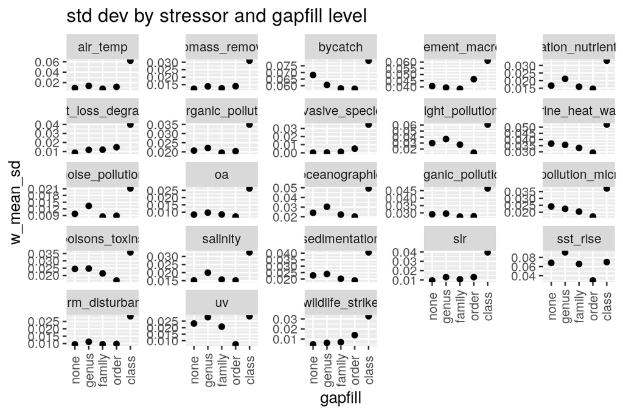

```r
ggplot(sd_by_str, aes(x = gapfill, y = w_mean_sd)) +
  geom_point() +
  facet_wrap(~stressor, scales = 'free_y') +
  theme(axis.text.x = element_text(angle = 90, vjust = .5)) +
  labs(title = 'std dev by stressor and gapfill level')
```

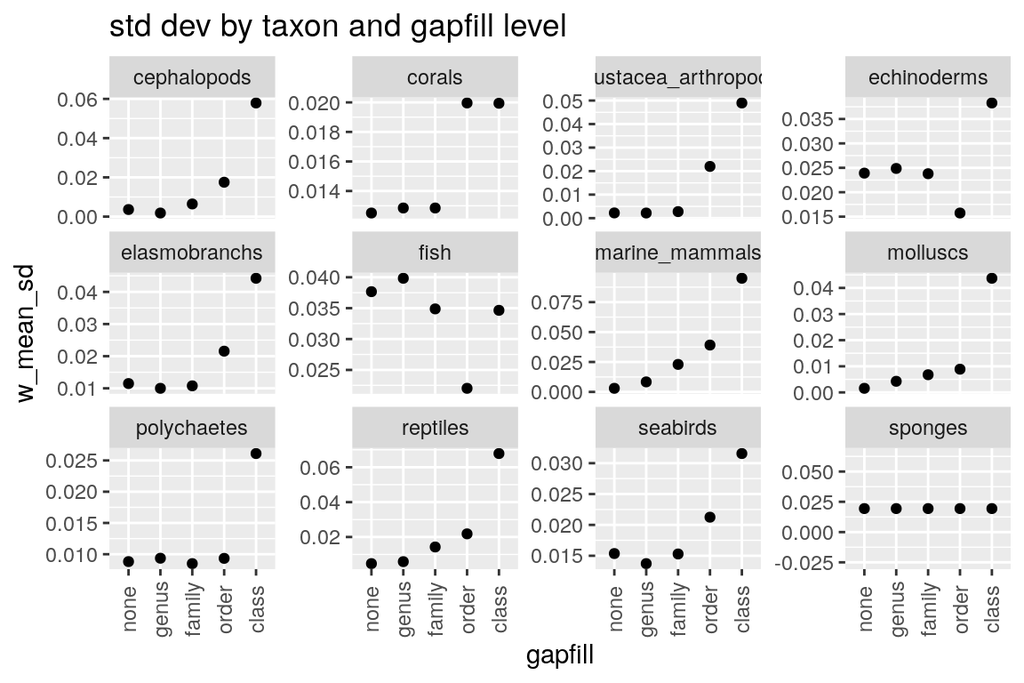

```r
ggplot(sd_by_taxon, aes(x = gapfill, y = w_mean_sd)) +
  geom_point() +
  facet_wrap(~taxon, scales = 'free_y') +
  theme(axis.text.x = element_text(angle = 90, vjust = .5)) +
  labs(title = 'std dev by taxon and gapfill level')
```

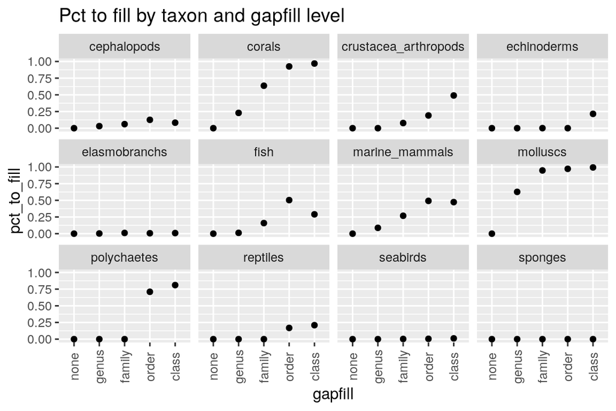

```r
ggplot(pct_pop_by_taxon, aes(x = gapfill, y = pct_to_fill)) +
  geom_point() +
  facet_wrap(~taxon) +
  theme(axis.text.x = element_text(angle = 90, vjust = .5)) +
  labs(title = 'Pct to fill by taxon and gapfill level')
```

## 2.6 Calculate gapfill counts and taxon means/sds

First let’s use the vulnerability gapfilling to fill in species up to class level (maximum) and write these out for posterity…

```r
vuln_vals <- read_csv(file.path(dir_mazu, 'pre_gapfill/vuln_gapfill_values.csv'), show_col_types = FALSE)
vuln_tx   <- read_csv(file.path(dir_mazu, 'pre_gapfill/vuln_gapfill_taxa.csv'), show_col_types = FALSE)
vuln_df <- vuln_tx %>%
  oharac::dt_join(vuln_vals, by = 'tx_id', type = 'left') %>%
  select(-tx_id, -n_spp_known, -n_prob) %>%
  distinct()

vuln_direct_match <- vuln_df %>%
  filter(!is.na(match_rank))

gf_ranks <- c('species', 'genus', 'family', 'order', 'class')

gf_list <- vector('list', length = length(gf_ranks)) %>%
  setNames(gf_ranks)

# gf_list[[1]] <- data.frame()

spp_done <- unique(vuln_direct_match$species)

for(i in 2:length(gf_ranks)) {
  ### i <- 2
  r <- gf_ranks[i]
  drop_ranks <- gf_ranks[c(1:(i-1))]
  rank_df <- vuln_df %>%
    filter(gapfill == r) %>%
    select(-all_of(drop_ranks)) %>%
    distinct()

  rank_gf_df <- spp_all_wide %>%
    filter(!species %in% spp_done) %>%
    inner_join(rank_df)

  spp_done <- c(spp_done, unique(rank_gf_df$species))

  gf_list[[i]] <- rank_gf_df
}

vuln_all_gf <- bind_rows(gf_list) %>%
  bind_rows(vuln_direct_match) %>%
  mutate(sd_vuln = ifelse(is.na(sd_vuln), 0, sd_vuln)) %>%
  select(-phylum)

vuln_gf_tx <- vuln_all_gf %>%
  select(class:species, taxon, gapfill, match_rank) %>%
  distinct() %>%
  arrange(species) %>%
  mutate(vuln_gf_id = 1:n())

vuln_gf_score <- vuln_all_gf %>%
  left_join(vuln_gf_tx %>% select(species, vuln_gf_id) %>% distinct(),
            by = 'species') %>%
  select(vuln_gf_id, stressor, vuln) %>%
  distinct() %>%
  mutate(vuln = round(vuln, 5)) %>%
  spread(stressor, vuln)

vuln_gf_sd <- vuln_all_gf %>%
  left_join(vuln_gf_tx %>% select(species, vuln_gf_id) %>% distinct(),
            by = 'species') %>%
  select(vuln_gf_id, stressor, sd_vuln) %>%
  distinct() %>%
  mutate(sd_vuln = round(sd_vuln, 5)) %>%
  spread(stressor, sd_vuln)

write_csv(vuln_gf_tx, file.path(dir_mazu, 'post_gapfill/vuln_gapfilled_all_tx.csv'))
write_csv(vuln_gf_score, file.path(dir_mazu, 'post_gapfill/vuln_gapfilled_all_score.csv'))
write_csv(vuln_gf_sd, file.path(dir_mazu, 'post_gapfill/vuln_gapfilled_all_sd.csv'))
```

… but for the purposes of the manuscript, let’s do this again just to the family level:

### 2.6.1 Outputs: Species matched or gapfilled to family level

These are just those species gapfilled to the family level (though include many downfilled from order or class). These are the values reported in Nat’s paper.

```r
vuln_gf_fam <- vuln_all_gf %>%
  filter(gapfill %in% c('none', 'genus', 'family'))

vuln_gf_fam_tx <- vuln_gf_fam %>%
  select(class:species, taxon, gapfill, match_rank) %>%
  distinct() %>%
  arrange(species) %>%
  mutate(vuln_gf_id = 1:n())

vuln_gf_fam_score <- vuln_gf_fam %>%
  left_join(vuln_gf_fam_tx %>% select(species, vuln_gf_id) %>% distinct(),
            by = 'species') %>%
  select(vuln_gf_id, stressor, vuln) %>%
  distinct() %>%
  mutate(vuln = round(vuln, 5)) %>%
  spread(stressor, vuln)

vuln_gf_fam_sd <- vuln_gf_fam %>%
  left_join(vuln_gf_fam_tx %>% select(species, vuln_gf_id) %>% distinct(),
            by = 'species') %>%
  select(vuln_gf_id, stressor, sd_vuln) %>%
  distinct() %>%
  mutate(sd_vuln = round(sd_vuln, 5)) %>%
  spread(stressor, sd_vuln)

write_csv(vuln_gf_fam_tx, here('_output', 'vuln_gapfilled_tx.csv'))
write_csv(vuln_gf_fam_score, here('_output', 'vuln_gapfilled_score.csv'))
write_csv(vuln_gf_fam_sd, here('_output', 'vuln_gapfilled_sd.csv'))
```

### 2.6.2 count of gapfill by taxon

Should be independent of stressor!

```r
gf_count <- vuln_all_gf %>%
  group_by(taxon, gapfill, match_rank) %>%
  summarize(n_spp = n_distinct(species)) %>%
  ungroup() %>%
  mutate(val = case_when(gapfill == 'none' ~ paste0('match: ', match_rank),
                         TRUE ~ paste0('gapfill: ', gapfill))) %>%
  select(taxon, val, n_spp) %>%
  spread(val, n_spp)
knitr::kable(gf_count)
```

| taxon | gapfill: class | gapfill: family | gapfill: genus | gapfill: order | match: class | match: family | match: genus | match: order | match: species |
| --- | --- | --- | --- | --- | --- | --- | --- | --- | --- |
| cephalopods | 10 | 33 | 20 | 6 | NA | 17 | 532 | NA | 220 |
| corals | 5531 | 312 | 11 | 3261 | NA | NA | 287 | NA | 1 |
| crustacea_arthropods | 19537 | 912 | NA | 12414 | 1094 | 811 | 93 | NA | 7 |
| echinoderms | 2634 | NA | NA | NA | NA | NA | 2 | 7565 | 98 |
| elasmobranchs | NA | 8 | 1 | 2 | NA | 626 | 571 | 6 | 35 |
| fish | 3118 | 3355 | 471 | 3814 | NA | 1331 | 534 | 5710 | 314 |
| marine_mammals | 2 | 71 | 23 | 10 | NA | 44 | 27 | NA | 47 |
| molluscs | 18116 | 6373 | 942 | 22908 | NA | NA | 130 | NA | 46 |
| polychaetes | 2618 | NA | NA | 5851 | NA | 1980 | NA | NA | NA |
| reptiles | NA | NA | NA | 22 | NA | 60 | 13 | NA | 10 |
| seabirds | NA | 4 | NA | NA | NA | 172 | 165 | NA | NA |
| sponges | NA | NA | NA | NA | 7482 | NA | NA | NA | NA |

```r
write_csv(gf_count, here('_output/gapfill_count.csv'))
```

### 2.6.3 Breakdown by taxon

Using species gapfilled to the family level

```r
tx_str_sum_outfile <- here('_output/taxon_str_vuln_summary.csv')
### unlink(tx_str_sum_outfile)
if(!file.exists(tx_str_sum_outfile) | reload) {

  taxa <- vuln_all_gf$taxon %>% unique() %>% sort()
  strs <- vuln_all_gf$stressor %>% unique() %>% sort()

  iters <- 10000

  tx_list <- vector('list', length = length(taxa)) %>%
    setNames(taxa)
  for(t in taxa) { ### t <- taxa[3]
    taxon_df <- vuln_all_gf %>%
      filter(gapfill %in% c('none', 'genus', 'family')) %>%
      filter(taxon == t)

    str_list <- parallel::mclapply(strs, mc.cores = 6,
      FUN = function(s) { ### s <- strs[1]
        taxon_str_df <- taxon_df %>%
          filter(stressor == s)
        message('Processing taxon ', t, ', ', s, ': nrows = ', nrow(taxon_str_df))
        n_known <- sum(taxon_str_df$gapfill == 'none')
        n_total <- n_distinct(taxon_str_df$species)

        mc_tx_str_df <- taxon_str_df %>%
          rowwise() %>%
          mutate(v = list(rnorm(iters, mean = vuln, sd = sd_vuln))) %>%
          unnest(v) %>%
          mutate(v = case_when(v < 0 ~ 0, v > 1 ~ 1, TRUE ~ v)) %>%
          group_by(taxon, stressor) %>%
          summarize(mean_vuln = mean(v) %>% round(5),
                    sd_vuln = sd(v) %>% round(5),
                    mean_vuln_known  = sum(v * (gapfill == 'none')) / sum(gapfill == 'none') %>%
                      round(5),
                    mean_vuln_filled = sum(v * (gapfill != 'none')) / sum(gapfill != 'none') %>%
                      round(5),
                    n_spp_known = n_known,
                    n_spp_total = n_total,
                    pct_spp_filled = round((n_total - n_known)/n_total * 100), 3)
        return(mc_tx_str_df)
      })

    tx_list[[t]] <- bind_rows(str_list)
  }

  tx_str_summary <- tx_list %>%
    bind_rows()
  write_csv(tx_str_summary, tx_str_sum_outfile)
}



tx_str_summary <- read_csv(tx_str_sum_outfile, show_col_types = FALSE)
DT::datatable(tx_str_summary)
```

|  | taxon | stressor | mean_vuln | sd_vuln | mean_vuln_known | mean_vuln_filled | n_spp_known | n_spp_total | pct_spp_filled | 3 |
| --- | --- | --- | --- | --- | --- | --- | --- | --- | --- | --- |
| 1 | cephalopods | air_temp | 0 | 0 | 0 | 0 | 769 | 822 | 6 | 3 |
| 2 | cephalopods | biomass_removal | 0.70874 | 0.0236 | 0.708546728429908 | 0.711502921552068 | 769 | 822 | 6 | 3 |
| 3 | cephalopods | bycatch | 0.38831 | 0.12395 | 0.389136586173828 | 0.376302610758035 | 769 | 822 | 6 | 3 |
| 4 | cephalopods | entanglement_macroplastic | 0.1375 | 0.09679 | 0.1382928485682 | 0.125993324577797 | 769 | 822 | 6 | 3 |
| 5 | cephalopods | eutrophication_nutrient_pollution | 0.48037 | 0.04833 | 0.480195610991017 | 0.482938002429173 | 769 | 822 | 6 | 3 |
| 6 | cephalopods | habitat_loss_degradation | 0.35109 | 0.02144 | 0.351019703314828 | 0.352184791709402 | 769 | 822 | 6 | 3 |
| 7 | cephalopods | inorganic_pollution | 0.41995 | 0.04177 | 0.419669876569884 | 0.423951776201449 | 769 | 822 | 6 | 3 |
| 8 | cephalopods | invasive_species | 0 | 0 | 0 | 0 | 769 | 822 | 6 | 3 |
| 9 | cephalopods | light_pollution | 0.09555 | 0.09513 | 0.0959340196151502 | 0.0899705047555708 | 769 | 822 | 6 | 3 |
| 10 | cephalopods | marine_heat_waves | 0.3567 | 0.06399 | 0.356836719309448 | 0.35475793022568 | 769 | 822 | 6 | 3 |

[output cut: 258 more lines]